# Pierwsze kroki z Big Data

December 1, 2021

## Literatura

1. Biecek, P., (2020). Przewodnik po pakiecie R, Warszawa: Oficyna Wydawnicza GIS.
2. Nowosad, J., (2020). Elementarz programisty: wstęp do programowania używając R. Poznań: Space A. Online: https://nowosad.github.io/elp/. ISBN: 978-83-953296-1-9

## Warunki zaliczenia

- Obecność
- Aktywność
- Projekt zaliczeniowy (ostatnie ćwiczenia)

## Zasady

- Nie używamy telefonów komórkowych
- Pracujemy rzetelnie
- Słuchamy siebie nawzajem
- Staramy się nie spóźniać
- Zaliczenie = projekt +/- obecność +/- aktywność

## Plan ćwiczeń

- Wprowadzenie do R i Rstudio + dokumentacja
- Zarządzanie danymi (typy zmiennych, obiekty, import danych)
- Wizualizacja danych
- Manipulacja danymi
- Tworzenie prostych map

## Środowisko R

- Wywodzi się z języka S opracowanego na potrzeby analizy danych w Bells Lab
- Obecnie rdzeń systemu napisany został w języku C
- Używany zarówno w korporacjach (np. Google, Novartis) jak i na uniwersytetach
- Duży nacisk na wizualizację danych

## Zalety R

- Darmowy i dostępny na wszystkie platformy
- Otwarty kod źródłowy
- Szybki, elastyczny i stabilny
- Duże możliwości graficzne
- Duża liczba tutoriali i system pomocy
- System pakietów

## Wady R

- Ograniczony interfejs graficzny
- Brak komercyjnego wsparcia technicznego
- Konieczność nauki języka
- Wysoki ‘próg wejścia’

## R i RStudio - instalacja

## Praca ze skryptami

- Skrypt to dokument R zawierający kod programowy oraz komentarze
- Komentarze wpisujemy po hashtagu #
- Komentarze są dla użytkownika
- Kod to zestaw funkcji i poleceń, które są zrozumiałe dla interpretera R

## R - pakiety podstawowe

```r
getOption("defaultPackages")
```

```
## [1] "datasets"  "utils"     "grDevices" "graphics"  "stats"     "methods"
```

## Podstawowe działania matematyczne

```r
2 * 2
```

```
## [1] 4
```

```r
10 + 2
```

```
## [1] 12
```

```r
2/45
```

```
## [1] 0.04444444
```

## Podstawowe działania matematyczne

```r
sqrt(10^6/(25 - 2) * 16)
```

```
## [1] 834.0577
```

```r
(28 + 2) * 3
```

```
## [1] 90
```

## Trochę trudniejsze działania matematyczne

- Jakie to działanie?

```r
D(expression(x^2 + 3 * x), "x")
```

```
## 2 * x + 3
```

## Operatory logiczne

```r
4 == 5  # jest równe
```

```
## [1] FALSE
```

```r
4 != 4  # nie jest równe
```

```
## [1] FALSE
```

```r
4 < 5
```

```
## [1] TRUE
```

```r
4 > 5
```

```
## [1] FALSE
```

## Operatory logiczne

```r
4 != 5  # nie jest
```

```
## [1] TRUE
```

```r
2 & 3 < 3  # i
```

```
## [1] FALSE
```

```r
1 | 3 > 2  # lub
```

```
## [1] TRUE
```

```r
4 & !6 < 5  # i nie
```

```
## [1] TRUE
```

## Tworzenie obiektów

```r
x <- 4 * pi + 2
# zerknij
x
```

```
## [1] 14.56637
```

## Tworzenie obiektów

```r
y <- c(10, 20, 30, 40, 50, 60, 70)
z <- (1:1000)
c <- c("Ala", "ma", "kota")
# zerknij
c
```

```
## [1] "Ala"  "ma"   "kota"
```

```r
y
```

```
## [1] 10 20 30 40 50 60 70
```

## Nazwy obiektów

Nazwy obiektów muszą zaczynać się od litery i mogą zawierać tylko litery, liczby, znaki ’_’ lub ‘.’ Np.:

```r
to_naprawde_dluga_nazwa <- 14.25
To.Naprawde.Dluga.Nazwa <- 25.14
```

## Działania na obiektach

Wykonując działania na obiektach wykonujemy działania na wszystkich elementach tych obiektów.

```r
y * z
```

```
##    [1]    10    40    90   160   250   360   490    80   180   300   440   600
##   [13]   780   980   150   320   510   720   950  1200  1470   220   460   720
##   [25]  1000  1300  1620  1960   290   600   930  1280  1650  2040  2450   360
##   [37]   740  1140  1560  2000  2460  2940   430   880  1350  1840  2350  2880
##   [49]  3430   500  1020  1560  2120  2700  3300  3920   570  1160  1770  2400
##   [61]  3050  3720  4410   640  1300  1980  2680  3400  4140  4900   710  1440
##   [73]  2190  2960  3750  4560  5390   780  1580  2400  3240  4100  4980  5880
##   [85]   850  1720  2610  3520  4450  5400  6370   920  1860  2820  3800  4800
##   [97]  5820  6860   990  2000  3030  4080  5150  6240  7350  1060  2140  3240
##  [109]  4360  5500  6660  7840  1130  2280  3450  4640  5850  7080  8330  1200
##  [121]  2420  3660  4920  6200  7500  8820  1270  2560  3870  5200  6550  7920
##  [133]  9310  1340  2700  4080  5480  6900  8340  9800  1410  2840  4290  5760
##  [145]  7250  8760 10290  1480  2980  4500  6040  7600  9180 10780  1550  3120
##  [157]  4710  6320  7950  9600 11270  1620  3260  4920  6600  8300 10020 11760
##  [169]  1690  3400  5130  6880  8650 10440 12250  1760  3540  5340  7160  9000
```

[output cut: 69 more lines]

## Działania na obiektach

```r
nowy.obiekt <- z/To.Naprawde.Dluga.Nazwa
```

## Dostęp do poszczególnych elementów obiektu

```r
y[2]
```

```
## [1] 20
```

```r
c[3]
```

```
## [1] "kota"
```

```r
y[5:7]
```

```
## [1] 50 60 70
```

## Data frame (ramka danych)

Tworzymy rankę danych składającą się z dwóch kolumn o nazwach ‘liczby’ i ‘litery’. Polecenie **data.frame()** tworzy ramkę.

```r
df <- data.frame(liczby = 1:26, litery = letters)

## dostep do kolumn przy pomocy znaku '$', czyli:
df$litery  ## ramka danych: 'df', kolumna: 'litery'
```

```
##  [1] "a" "b" "c" "d" "e" "f" "g" "h" "i" "j" "k" "l" "m" "n" "o" "p" "q" "r" "s"
## [20] "t" "u" "v" "w" "x" "y" "z"
```

## Dostęp do poszczególnych elementów obiektu - data frame

```r
df[1, ]  ## pierwszy wiersz
```

```
##   liczby litery
## 1      1      a
```

```r
df[, 1]  ## pierwsza kolumna
```

```
##  [1]  1  2  3  4  5  6  7  8  9 10 11 12 13 14 15 16 17 18 19 20 21 22 23 24 25
## [26] 26
```

```r
df[5, 2]  ## piaty element drugiej kolumny
```

```
## [1] "e"
```

## Większa ramka - polecenie rep()

```r
## polecenie **rep()** replikuje dana sekwencje zadana
## liczbe razy...  Na przyklad:
rep(c(3, 1, 8), 5)
```

```
##  [1] 3 1 8 3 1 8 3 1 8 3 1 8 3 1 8
```

```r
## teraz ramka
big.df <- data.frame(liczby = rep(1:26, 10^6), litery = rep(letters,
    10^6))
```

## Funkcje

R posiada ogromną kolekcję wbudowanych funkcji, np.

- class(), sort(), rm(), min(), max(), mean(), length(), table(), sum(), sd()
- ogólna struktura użycia funkcji: *funkcja(arg1, arg2, arg3, …)*

### Korzystanie z dokumentacji technicznej, np.

```r
help("table")
```

```
## starting httpd help server ... done
```

Oprócz dokumentacji technicznej w internecie znaleźć można znaleźć sporo przykładów, tutoriali, fragmentów kodu, rozwiązań dotyczących niemal **każdego** znanego problemu.

## Zadanie

- Utwórz dowolny obiekt składający się z minimum 100 liczb. Zastosuj powyższe funkcje na tym obiekcie wg schematu: *nazwa_funkcji(nazwa_obiektu)*.
- Do czego służą wskazane funkcje?

## Instalowanie i wczytywanie pakietów

```r
# packages <- c('tidyverse', 'nycflights13')
# install.packages(packages) ## zainstaluj wskazane
# pakiety
library(tidyverse)  ## wczytaj pakiety 'tidyverse'
```

## instalowanie i wczytywanie pakietów

Samodzielnie wczytaj pakiet ‘nycflights’

## instalowanie i wczytywanie pakietów

Samodzielnie wczytaj pakiet ‘nycflights’

```r
library(nycflights13)
## Po wczytaniu pakietu uzyskujemy dostep do bazy
## 'flights'
flights <- flights
```

## Pierwsze kroki z danymi

Baza dotycząca odlotów z NYC https://cran.r-project.org/web/packages/nycflights13/nycflights13.pdf

- Jakie zmienne są w tej bazie? Opisz je w komentarzach wg schematu **nazwa zmiennej, opis zmiennej**

## Eksploracja danych

Polecenie **‘summary()’** dostarcza podstawowych danych na temat zbioru bądź wybranej zmiennej.

```r
summary(flights)  ## caly zbiór
```

```
##       year          month             day           dep_time    sched_dep_time
##  Min.   :2013   Min.   : 1.000   Min.   : 1.00   Min.   :   1   Min.   : 106
##  1st Qu.:2013   1st Qu.: 4.000   1st Qu.: 8.00   1st Qu.: 907   1st Qu.: 906
##  Median :2013   Median : 7.000   Median :16.00   Median :1401   Median :1359
##  Mean   :2013   Mean   : 6.549   Mean   :15.71   Mean   :1349   Mean   :1344
##  3rd Qu.:2013   3rd Qu.:10.000   3rd Qu.:23.00   3rd Qu.:1744   3rd Qu.:1729
##  Max.   :2013   Max.   :12.000   Max.   :31.00   Max.   :2400   Max.   :2359
##                                                  NA's   :8255
##    dep_delay          arr_time    sched_arr_time   arr_delay
##  Min.   : -43.00   Min.   :   1   Min.   :   1   Min.   : -86.000
##  1st Qu.:  -5.00   1st Qu.:1104   1st Qu.:1124   1st Qu.: -17.000
##  Median :  -2.00   Median :1535   Median :1556   Median :  -5.000
##  Mean   :  12.64   Mean   :1502   Mean   :1536   Mean   :   6.895
##  3rd Qu.:  11.00   3rd Qu.:1940   3rd Qu.:1945   3rd Qu.:  14.000
##  Max.   :1301.00   Max.   :2400   Max.   :2359   Max.   :1272.000
##  NA's   :8255      NA's   :8713                  NA's   :9430
##    carrier              flight       tailnum             origin
##  Length:336776      Min.   :   1   Length:336776      Length:336776
##  Class :character   1st Qu.: 553   Class :character   Class :character
##  Mode  :character   Median :1496   Mode  :character   Mode  :character
##                     Mean   :1972
##                     3rd Qu.:3465
##                     Max.   :8500
##
##      dest              air_time        distance         hour
##  Length:336776      Min.   : 20.0   Min.   :  17   Min.   : 1.00
##  Class :character   1st Qu.: 82.0   1st Qu.: 502   1st Qu.: 9.00
##  Mode  :character   Median :129.0   Median : 872   Median :13.00
##                     Mean   :150.7   Mean   :1040   Mean   :13.18
##                     3rd Qu.:192.0   3rd Qu.:1389   3rd Qu.:17.00
##                     Max.   :695.0   Max.   :4983   Max.   :23.00
##                     NA's   :9430
##      minute        time_hour
##  Min.   : 0.00   Min.   :2013-01-01 05:00:00
##  1st Qu.: 8.00   1st Qu.:2013-04-04 13:00:00
##  Median :29.00   Median :2013-07-03 10:00:00
##  Mean   :26.23   Mean   :2013-07-03 05:22:54
##  3rd Qu.:44.00   3rd Qu.:2013-10-01 07:00:00
##  Max.   :59.00   Max.   :2013-12-31 23:00:00
##
```

## Eksploracja danych

```r
summary(flights$arr_delay)  ## kolumna 'arr_delay'
```

```
##     Min.  1st Qu.   Median     Mean  3rd Qu.     Max.     NA's
##  -86.000  -17.000   -5.000    6.895   14.000 1272.000     9430
```

## Eksploracja danych

```r
summary(flights$air_time)  ## kolumna 'air_time'
```

```
##    Min. 1st Qu.  Median    Mean 3rd Qu.    Max.    NA's
##    20.0    82.0   129.0   150.7   192.0   695.0    9430
```

## Wizualizacja danych

Są dwa ogólne sposoby na wizualizację danych:

- Pierwszy wykorzystuje bazowe pakiety R (funkcja **plot()** i pochodne).
- Drugi opiera się na zewnętrznym pakiecie **ggplot2** i bywa używany częściej ze względu na bardziej przystępną estetykę, a także możliwość zapisania wykresu jako obiektu w przestrzeni roboczej.

## Wizualizacja danych

zależność pomiędzy opóźnieniem a czasem lotu - **ggplot**

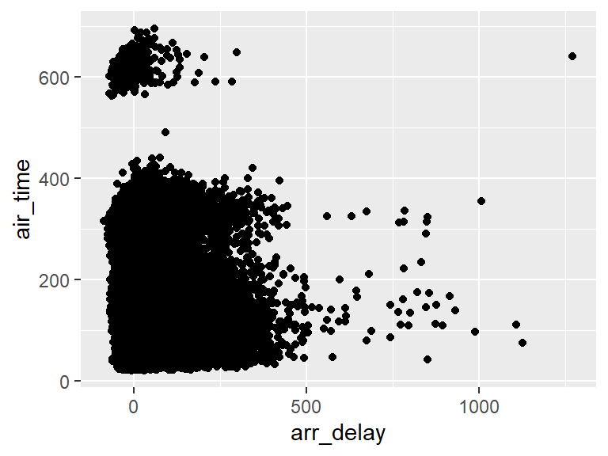

```r
ggplot(data = flights) +       ## polecenie ggplot inicjuje wykres
  geom_point(aes(x = arr_delay, y = air_time)) ## rysujemy punkty
```

## Wizualizacja danych

zależność pomiędzy opóźnieniem a czasem lotu - **base R**

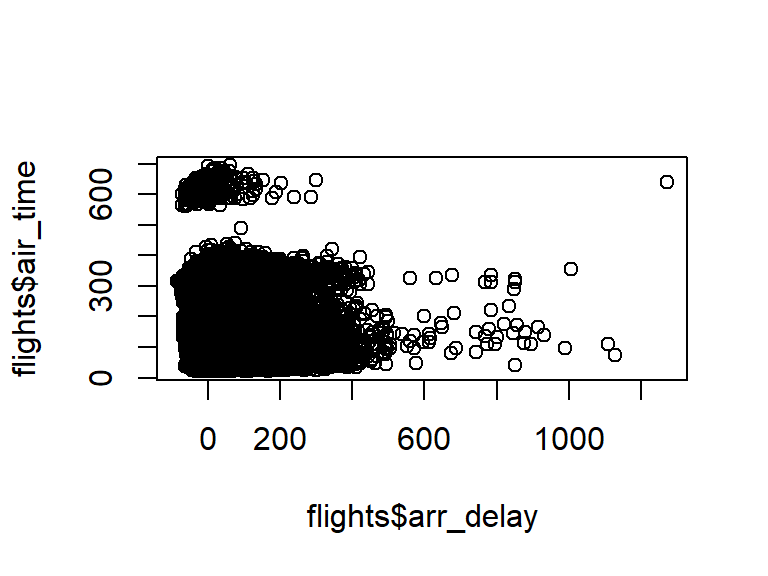

```r
plot(flights$arr_delay, flights$air_time)
```

## Wizualizacja danych

Opcje wykresu ggplot

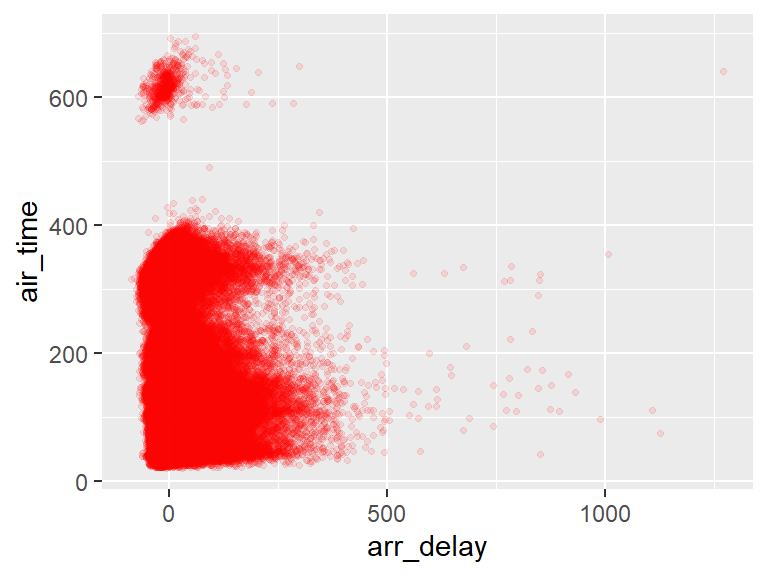

```r
## kolor: czerwony, rozmiar: 0.9, nasycenie: 10%
ggplot(data = flights) + geom_point(aes(x = arr_delay, y = air_time,
    ), color = "red", size = 0.9, alpha = 0.1)
```

## Zadanie

- Narysuj histogram dla opóźnień przylotów (arr_delay). Co przedstawia oś X, a co oś Y?

## Zadanie

- Narysuj histogram dla opóźnień przylotów (arr_delay). Co przedstawia oś X, a co oś Y?

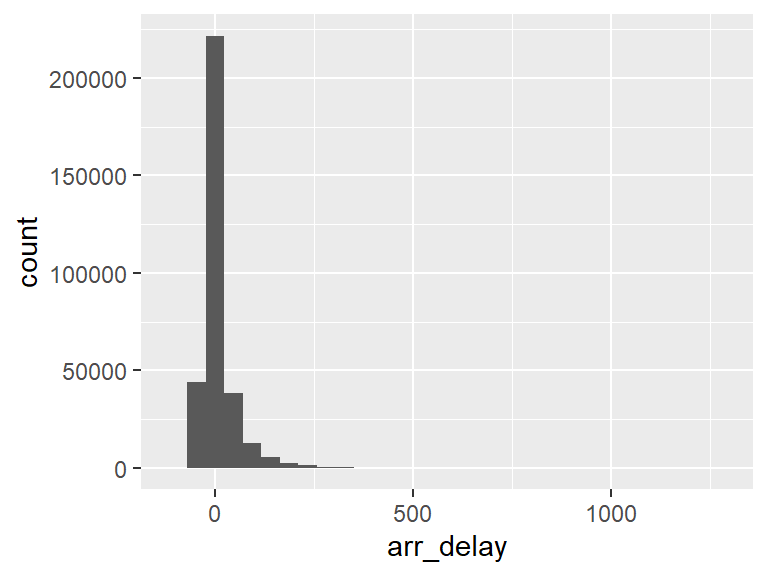

```r
ggplot(data = flights) + geom_histogram(aes(x = arr_delay))
```

## Zadanie - dopasowanie wykresu

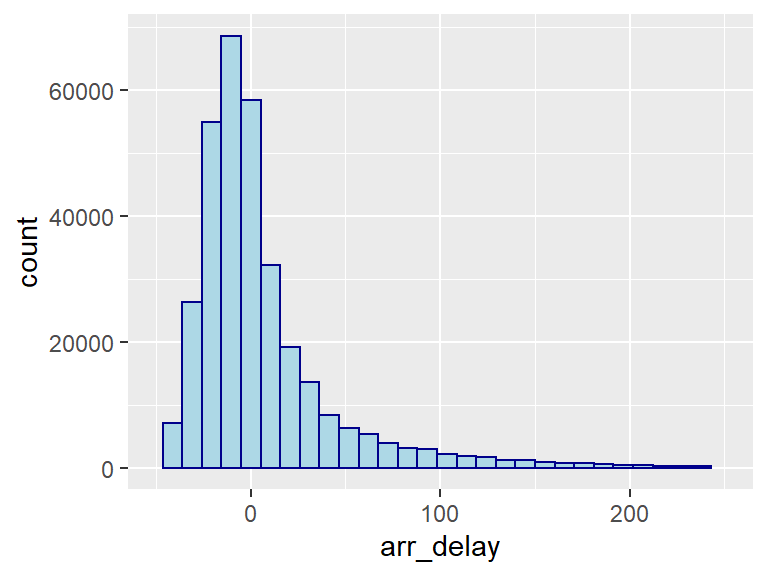

```r
ggplot(data = flights) +
  xlim(-50, 250) +        ## limity osi X
  ## dodatkowo kolor ramki i wypełnienia
  geom_histogram(aes(x = arr_delay), color="darkblue", fill="lightblue")
```

## Zadanie - wykres słupkowy

Narysuj wykres słupkowy dla nazw przewoźników. Jacy operatorzy pojawiają się w zestawieniu najczęściej (pierwsze trzy miejsca)?

## Zadanie - wykres słupkowy

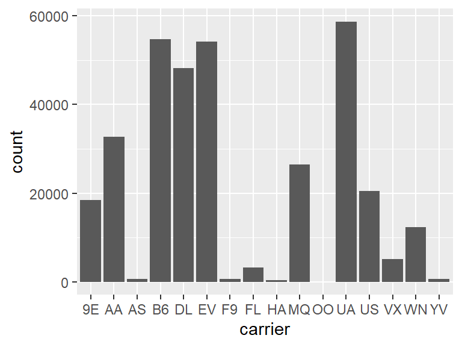

```r
ggplot(data = flights) + geom_bar(aes(x = carrier))
```

## Wykres słupkowy

Wykres posortowany ze zmianą kolorów słupków i ich obramowania + zmiana templatki wykresu na ‘bw’

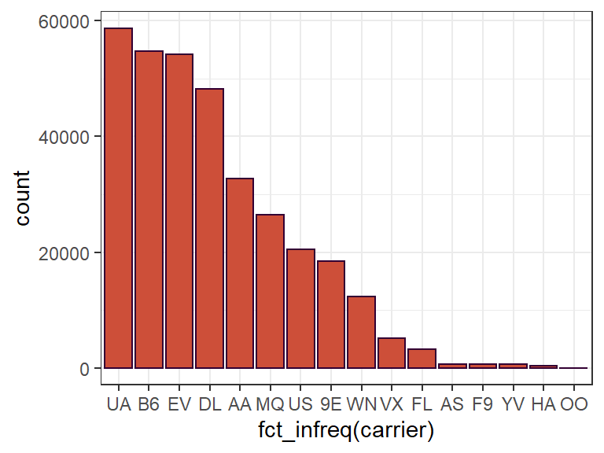

```r
ggplot(data=flights) +
  geom_bar(aes(x=fct_infreq(carrier)), color="#330033", fill="tomato3") +
  theme_bw()
```

## Wykres słupkowy

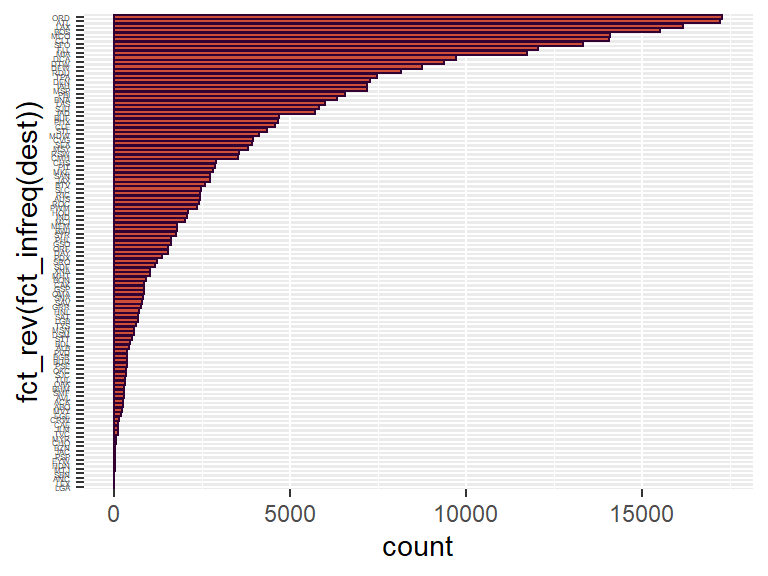

```r
ggplot(data=flights) +
  geom_bar(aes(x=fct_rev(fct_infreq(dest))),
           color="#330033", fill="tomato3") +
  coord_flip() +
  theme(axis.text.y = element_text(size = 3))
```

## Wykresy - templatki

Każdy wykres możemy stworzyć w oparciu o kilka podstawowych wzorów, np.:

- *theme_grey()*
- *theme_bw()*
- *theme_void()*
- *theme_light()*
- *theme_minimal()*

## Praca z danymi - pakiet ‘dplyr’

- Filtrowanie obserwacji *filter()*
- Zmienianie kolejności danych *reorder()*
- Wybieranie zmiennych *select()*
- Tworzenie nowych zmiennych jako funkcja istniejących *mutate()* i *transmute*
- Łączenie wielu zmiennych w jedną *summarise()* i *group_by()*

## Filtrowanie obserwacji

Dzięki funkcji *filter()* możemy wybierać obserwacje po ich wartościach

```r
filter(flights, month == 1, day == 1)
```

```
## # A tibble: 842 x 19
##     year month   day dep_time sched_dep_time dep_delay arr_time sched_arr_time
##    <int> <int> <int>    <int>          <int>     <dbl>    <int>          <int>
##  1  2013     1     1      517            515         2      830            819
##  2  2013     1     1      533            529         4      850            830
##  3  2013     1     1      542            540         2      923            850
##  4  2013     1     1      544            545        -1     1004           1022
##  5  2013     1     1      554            600        -6      812            837
##  6  2013     1     1      554            558        -4      740            728
##  7  2013     1     1      555            600        -5      913            854
##  8  2013     1     1      557            600        -3      709            723
##  9  2013     1     1      557            600        -3      838            846
## 10  2013     1     1      558            600        -2      753            745
## # ... with 832 more rows, and 11 more variables: arr_delay <dbl>,
## #   carrier <chr>, flight <int>, tailnum <chr>, origin <chr>, dest <chr>,
## #   air_time <dbl>, distance <dbl>, hour <dbl>, minute <dbl>, time_hour <dttm>
```

## Filtrowanie obserwacji

Utwórz nowy obiekt o nazwie ‘luty25’, który zawierał będzie wszystkie loty z 25 lutego.

## Filtrowanie obserwacji

Utwórz nowy obiekt o nazwie ‘luty25’, który zawierał będzie wszystkie loty z 25 lutego.

```r
luty25 <- filter(flights, month == 2, day == 25)
```

## Filtrowanie obserwacji

Wybierz loty, które odbyły się w listopadzie lub grudniu.

```r
filter(flights, month == 11 | month == 12)
```

```
## # A tibble: 55,403 x 19
##     year month   day dep_time sched_dep_time dep_delay arr_time sched_arr_time
##    <int> <int> <int>    <int>          <int>     <dbl>    <int>          <int>
##  1  2013    11     1        5           2359         6      352            345
##  2  2013    11     1       35           2250       105      123           2356
##  3  2013    11     1      455            500        -5      641            651
##  4  2013    11     1      539            545        -6      856            827
##  5  2013    11     1      542            545        -3      831            855
##  6  2013    11     1      549            600       -11      912            923
##  7  2013    11     1      550            600       -10      705            659
##  8  2013    11     1      554            600        -6      659            701
##  9  2013    11     1      554            600        -6      826            827
## 10  2013    11     1      554            600        -6      749            751
## # ... with 55,393 more rows, and 11 more variables: arr_delay <dbl>,
## #   carrier <chr>, flight <int>, tailnum <chr>, origin <chr>, dest <chr>,
## #   air_time <dbl>, distance <dbl>, hour <dbl>, minute <dbl>, time_hour <dttm>
```

## Filtrowanie obserwacji

Loty, których odlot i przylot nie był opóźniony o więcej niż 30 minut.

```r
filter(flights, arr_delay <= 30 & dep_delay <= 30)
```

```
## # A tibble: 267,842 x 19
##     year month   day dep_time sched_dep_time dep_delay arr_time sched_arr_time
##    <int> <int> <int>    <int>          <int>     <dbl>    <int>          <int>
##  1  2013     1     1      517            515         2      830            819
##  2  2013     1     1      533            529         4      850            830
##  3  2013     1     1      544            545        -1     1004           1022
##  4  2013     1     1      554            600        -6      812            837
##  5  2013     1     1      554            558        -4      740            728
##  6  2013     1     1      555            600        -5      913            854
##  7  2013     1     1      557            600        -3      709            723
##  8  2013     1     1      557            600        -3      838            846
##  9  2013     1     1      558            600        -2      753            745
## 10  2013     1     1      558            600        -2      849            851
## # ... with 267,832 more rows, and 11 more variables: arr_delay <dbl>,
## #   carrier <chr>, flight <int>, tailnum <chr>, origin <chr>, dest <chr>,
## #   air_time <dbl>, distance <dbl>, hour <dbl>, minute <dbl>, time_hour <dttm>
```

## Zadania

Znajdź wszystkie loty, które:

- Miały opóźnienie powyżej dwóch godzin
- Leciały do Houston (IAH lub HOU)
- Operatorem był United, American lub Delta
- Odleciały w lecie (czerwiec, lipiec, sierpień)
- Loty, które przyleciały z ponad dwugodzinnym opóźnieniem, ale wystartowały planowo (z dokładnością do 5 minut)

## Zadania

- Loty, które miały opóźnienie powyżej dwóch godzin

```r
filter(flights, arr_delay > 120 | dep_delay > 120)
```

```
## # A tibble: 11,422 x 19
##     year month   day dep_time sched_dep_time dep_delay arr_time sched_arr_time
##    <int> <int> <int>    <int>          <int>     <dbl>    <int>          <int>
##  1  2013     1     1      811            630       101     1047            830
##  2  2013     1     1      848           1835       853     1001           1950
##  3  2013     1     1      957            733       144     1056            853
##  4  2013     1     1     1114            900       134     1447           1222
##  5  2013     1     1     1505           1310       115     1638           1431
##  6  2013     1     1     1525           1340       105     1831           1626
##  7  2013     1     1     1540           1338       122     2020           1825
##  8  2013     1     1     1549           1445        64     1912           1656
##  9  2013     1     1     1558           1359       119     1718           1515
## 10  2013     1     1     1732           1630        62     2028           1825
## # ... with 11,412 more rows, and 11 more variables: arr_delay <dbl>,
## #   carrier <chr>, flight <int>, tailnum <chr>, origin <chr>, dest <chr>,
## #   air_time <dbl>, distance <dbl>, hour <dbl>, minute <dbl>, time_hour <dttm>
```

## Zadania

- Loty, które miały destynacje Houston (IAH lub HOU)

```r
filter(flights, dest == "IAH" | dest == "HOU")
```

```
## # A tibble: 9,313 x 19
##     year month   day dep_time sched_dep_time dep_delay arr_time sched_arr_time
##    <int> <int> <int>    <int>          <int>     <dbl>    <int>          <int>
##  1  2013     1     1      517            515         2      830            819
##  2  2013     1     1      533            529         4      850            830
##  3  2013     1     1      623            627        -4      933            932
##  4  2013     1     1      728            732        -4     1041           1038
##  5  2013     1     1      739            739         0     1104           1038
##  6  2013     1     1      908            908         0     1228           1219
##  7  2013     1     1     1028           1026         2     1350           1339
##  8  2013     1     1     1044           1045        -1     1352           1351
##  9  2013     1     1     1114            900       134     1447           1222
## 10  2013     1     1     1205           1200         5     1503           1505
## # ... with 9,303 more rows, and 11 more variables: arr_delay <dbl>,
## #   carrier <chr>, flight <int>, tailnum <chr>, origin <chr>, dest <chr>,
## #   air_time <dbl>, distance <dbl>, hour <dbl>, minute <dbl>, time_hour <dttm>
```

## Zadania

- Loty, których operatorem był United, American lub Delta

```r
filter(flights, carrier == "UA" | carrier == "AA" | carrier ==
    "DL")
```

```
## # A tibble: 139,504 x 19
##     year month   day dep_time sched_dep_time dep_delay arr_time sched_arr_time
##    <int> <int> <int>    <int>          <int>     <dbl>    <int>          <int>
##  1  2013     1     1      517            515         2      830            819
##  2  2013     1     1      533            529         4      850            830
##  3  2013     1     1      542            540         2      923            850
##  4  2013     1     1      554            600        -6      812            837
##  5  2013     1     1      554            558        -4      740            728
##  6  2013     1     1      558            600        -2      753            745
##  7  2013     1     1      558            600        -2      924            917
##  8  2013     1     1      558            600        -2      923            937
##  9  2013     1     1      559            600        -1      941            910
## 10  2013     1     1      559            600        -1      854            902
## # ... with 139,494 more rows, and 11 more variables: arr_delay <dbl>,
## #   carrier <chr>, flight <int>, tailnum <chr>, origin <chr>, dest <chr>,
## #   air_time <dbl>, distance <dbl>, hour <dbl>, minute <dbl>, time_hour <dttm>
```

## Zadania

- Loty, które odleciały latem

```r
filter(flights, month == 6 | month == 7 | month == 8)
```

```
## # A tibble: 86,995 x 19
##     year month   day dep_time sched_dep_time dep_delay arr_time sched_arr_time
##    <int> <int> <int>    <int>          <int>     <dbl>    <int>          <int>
##  1  2013     6     1        2           2359         3      341            350
##  2  2013     6     1      451            500        -9      624            640
##  3  2013     6     1      506            515        -9      715            800
##  4  2013     6     1      534            545       -11      800            829
##  5  2013     6     1      538            545        -7      925            922
##  6  2013     6     1      539            540        -1      832            840
##  7  2013     6     1      546            600       -14      850            910
##  8  2013     6     1      551            600        -9      828            850
##  9  2013     6     1      552            600        -8      647            655
## 10  2013     6     1      553            600        -7      700            711
## # ... with 86,985 more rows, and 11 more variables: arr_delay <dbl>,
## #   carrier <chr>, flight <int>, tailnum <chr>, origin <chr>, dest <chr>,
## #   air_time <dbl>, distance <dbl>, hour <dbl>, minute <dbl>, time_hour <dttm>
```

## Zadania

- Loty, które przyleciały z ponad dwugodzinnym opóźnieniem, ale wystartowały planowo (z dokładnością do 5 minut)

```r
filter(flights, arr_delay > 120 & dep_delay <= 5)
```

```
## # A tibble: 36 x 19
##     year month   day dep_time sched_dep_time dep_delay arr_time sched_arr_time
##    <int> <int> <int>    <int>          <int>     <dbl>    <int>          <int>
##  1  2013     1    27     1419           1420        -1     1754           1550
##  2  2013    10     7     1350           1350         0     1736           1526
##  3  2013    10     7     1357           1359        -2     1858           1654
##  4  2013    10    16      657            700        -3     1258           1056
##  5  2013    11     1      658            700        -2     1329           1015
##  6  2013     3     8     1246           1245         1     1552           1350
##  7  2013     3    18     1844           1847        -3       39           2219
##  8  2013     4    17     1635           1640        -5     2049           1845
##  9  2013     4    18      558            600        -2     1149            850
## 10  2013     4    18      655            700        -5     1213            950
## # ... with 26 more rows, and 11 more variables: arr_delay <dbl>, carrier <chr>,
## #   flight <int>, tailnum <chr>, origin <chr>, dest <chr>, air_time <dbl>,
## #   distance <dbl>, hour <dbl>, minute <dbl>, time_hour <dttm>
```

## Wybieranie kolumn

Funkcja **select()** umożliwia wybieranie kolumn. Nie jest rzadkością otrzymywanie zbiorów danych z setkami, a nawet tysiącami zmiennych. W takim przypadku, pierwszym wyzwaniem jest często zawężenie zbioru.

**select()** pozwala na szybkie przybliżenie użytecznego podzbioru przy użyciu operacji opartych na nazwach zmiennych.

## Wybieranie kolumn

```r
## wybieranie po nazwie kolumny
select(flights, year, month, day)
```

```
## # A tibble: 336,776 x 3
##     year month   day
##    <int> <int> <int>
##  1  2013     1     1
##  2  2013     1     1
##  3  2013     1     1
##  4  2013     1     1
##  5  2013     1     1
##  6  2013     1     1
##  7  2013     1     1
##  8  2013     1     1
##  9  2013     1     1
## 10  2013     1     1
## # ... with 336,766 more rows
```

## Wybieranie kolumn

```r
## wybieranie zakresu kolumn
select(flights, year:day)
```

```
## # A tibble: 336,776 x 3
##     year month   day
##    <int> <int> <int>
##  1  2013     1     1
##  2  2013     1     1
##  3  2013     1     1
##  4  2013     1     1
##  5  2013     1     1
##  6  2013     1     1
##  7  2013     1     1
##  8  2013     1     1
##  9  2013     1     1
## 10  2013     1     1
## # ... with 336,766 more rows
```

## Wybieranie kolumn

Jeżeli nie chcemy pozbyć się wszystkich niewskazanych funkcją **select()** zmiennych, warto zastosować parametr **everything()**

```r
select(flights, time_hour, air_time, everything())
```

```
## # A tibble: 336,776 x 19
##    time_hour           air_time  year month   day dep_time sched_dep_time
##    <dttm>                 <dbl> <int> <int> <int>    <int>          <int>
##  1 2013-01-01 05:00:00      227  2013     1     1      517            515
##  2 2013-01-01 05:00:00      227  2013     1     1      533            529
##  3 2013-01-01 05:00:00      160  2013     1     1      542            540
##  4 2013-01-01 05:00:00      183  2013     1     1      544            545
##  5 2013-01-01 06:00:00      116  2013     1     1      554            600
##  6 2013-01-01 05:00:00      150  2013     1     1      554            558
##  7 2013-01-01 06:00:00      158  2013     1     1      555            600
##  8 2013-01-01 06:00:00       53  2013     1     1      557            600
##  9 2013-01-01 06:00:00      140  2013     1     1      557            600
## 10 2013-01-01 06:00:00      138  2013     1     1      558            600
## # ... with 336,766 more rows, and 12 more variables: dep_delay <dbl>,
## #   arr_time <int>, sched_arr_time <int>, arr_delay <dbl>, carrier <chr>,
## #   flight <int>, tailnum <chr>, origin <chr>, dest <chr>, distance <dbl>,
## #   hour <dbl>, minute <dbl>
```

## Wybieranie kolumn

Istnieje kilka funkcji pomocniczych, których można użyć wewnątrz **select()**:

- **starts_with(“abc”)**: wybiera nazwy, które zaczynają się od “abc”.
- **ends_with(“xyz”)**: wybiera nazwy, które kończą się na “xyz”.
- **contains(“ijk”)**: wybiera nazwy, które zawierają “ijk”.

## Zadanie

Wymyśl jak najwięcej sposobów na to, aby wybrać następujące zmienne ze zbioru **flights**:

- dep_time,
- dep_delay,
- arr_time,
- arr_delay

## Dodawanie nowych zmiennych

Poza wybieraniem zestawów istniejących kolumn, często przydatne jest dodawanie nowych zmiennych, które są pochodnymi istniejących kolumn.  
To jest właśnie zadanie funkcji **mutate()**. **mutate()** dodaje nowe kolumny na końcu zbioru danych.  
Dodatkowo możemy wykorzystać **transmute()**, która dodaje nowe zmienne, jednocześnie usuwając wszystkie pozostałe.

## Dodawanie nowych zmiennych

Utwórzmy mniejszy zbiór danych

```r
flights_sml <- select(flights, year:day, ends_with("delay"),
    distance, air_time)
```

## Dodawanie nowych zmiennych

```r
# pracujemy na mniejszym zbiorze
mutate(flights_sml,
  gain = dep_delay - arr_delay,
  speed = distance / air_time * 60
)
```

```
## # A tibble: 336,776 x 9
##     year month   day dep_delay arr_delay distance air_time  gain speed
##    <int> <int> <int>     <dbl>     <dbl>    <dbl>    <dbl> <dbl> <dbl>
##  1  2013     1     1         2        11     1400      227    -9  370.
##  2  2013     1     1         4        20     1416      227   -16  374.
##  3  2013     1     1         2        33     1089      160   -31  408.
##  4  2013     1     1        -1       -18     1576      183    17  517.
##  5  2013     1     1        -6       -25      762      116    19  394.
##  6  2013     1     1        -4        12      719      150   -16  288.
##  7  2013     1     1        -5        19     1065      158   -24  404.
##  8  2013     1     1        -3       -14      229       53    11  259.
##  9  2013     1     1        -3        -8      944      140     5  405.
## 10  2013     1     1        -2         8      733      138   -10  319.
## # ... with 336,766 more rows
```

## Dodawanie nowych zmiennych

```r
# jeżeli chcesz  zostawić tylko wskazane zmienne użyj funkcji transmute()
transmute(flights,
  dep_time,
  hour = dep_time %/% 100, ## dzielenie przez 100 bez reszty
  minute = dep_time %% 100 ## dzielenie przez 100 - sama reszta
)
```

```
## # A tibble: 336,776 x 3
##    dep_time  hour minute
##       <int> <dbl>  <dbl>
##  1      517     5     17
##  2      533     5     33
##  3      542     5     42
##  4      544     5     44
##  5      554     5     54
##  6      554     5     54
##  7      555     5     55
##  8      557     5     57
##  9      557     5     57
## 10      558     5     58
## # ... with 336,766 more rows
```

## Grupowanie i podsumowania

Funkcja **summarise()** bywa często łączona z funkcją **group_by()**. Zmienia to jednostkę analizy z kompletnego zbioru danych na poszczególne grupy.

```r
summarise(flights, delay = mean(dep_delay, na.rm = TRUE))
```

```
## # A tibble: 1 x 1
##   delay
##   <dbl>
## 1  12.6
```

## Grupowanie i podsumowania

Jeśli zastosujemy kod do danych pogrupowanych według daty, otrzymamy średnie opóźnienie na datę:

```r
# grupujemy obserwacje (loty) wg dni
by_day <- group_by(flights, year, month, day)
# srednie opóznienie dla kazdego dnia
summarise(by_day, delay = mean(dep_delay, na.rm = TRUE))
```

```
## # A tibble: 365 x 4
## # Groups:   year, month [12]
##     year month   day delay
##    <int> <int> <int> <dbl>
##  1  2013     1     1 11.5
##  2  2013     1     2 13.9
##  3  2013     1     3 11.0
##  4  2013     1     4  8.95
##  5  2013     1     5  5.73
##  6  2013     1     6  7.15
##  7  2013     1     7  5.42
##  8  2013     1     8  2.55
##  9  2013     1     9  2.28
## 10  2013     1    10  2.84
## # ... with 355 more rows
```

## Łączenie wielu operacji

```r
# grupowanie wg destynacji
by_dest <- group_by(flights, dest)
# tworzymy zbiór ze srednimi opóznieniami w ramach
# destynacji
delay <- summarise(by_dest, count = n(), dist = mean(distance,
    na.rm = TRUE), delay = mean(arr_delay, na.rm = TRUE))
```

## Łączenie wielu operacji

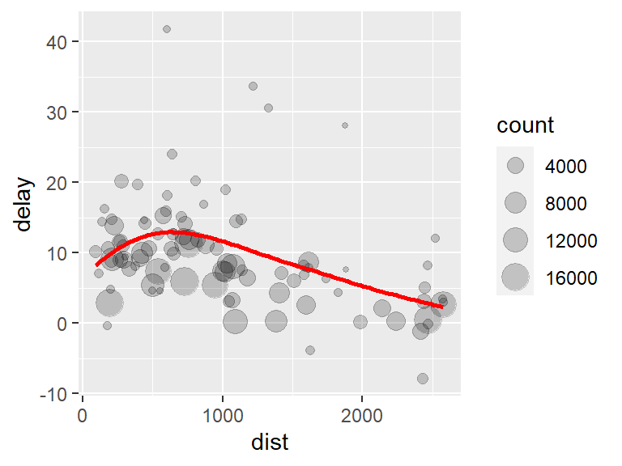

```r
# eliminujemy obserwacje odstające
delay <- filter(delay, count > 20, dest != "HNL")
ggplot(data = delay, mapping = aes(x = dist, y = delay)) +
  geom_point(aes(size = count), alpha = 0.2) +
  geom_smooth(col="red", se = FALSE) ## linia regresji
```